# Speech/gesture tradeoffs in natural interactions

Dan Yurovsky, Maddie Meyers, Nicole Burke, Susan Goldin-Meadow, and Amanda Woodward

2017-07-18

## R Markdown

Load in coded data and show how many children we have at each age

```r
files <-list.files("ldp_data/fixed_data/",
                   "*.csv", full.names = TRUE)

loaded_subjs <- map(files, fread, sep=",", na.strings = c("NA", "")) %>%
  bind_rows() %>%
  mutate(age = 10+session*4) %>%
  group_by(subj, age) %>%
  mutate(time = 1:n()) %>%
  select(time, subj, age, person, spoken_obj, gestured_obj, referent, gloss, chat)

demos <- loaded_subjs %>%
  select(subj,age) %>%
  distinct(subj,age, .keep_all = TRUE) %>%
  group_by(age) %>%
  summarise(n = n())

datatable(demos, rownames = FALSE, options = list(searching = FALSE), width = 300)
```

| age | n |
| --- | --- |
| 14 | 10 |
| 18 | 10 |
| 22 | 10 |
| 26 | 10 |

Let’s look at the referents first

```r
# Compute the frequency of each distinct referent
referents <- loaded_subjs %>%
  ungroup() %>%
  select(referent) %>%
  filter(!is.na(referent)) %>%
  map(~str_split(string = ., pattern = ";")) %>% #split multiple-referents
  unlist() %>%
  map(str_trim) %>% # trim white space
  unlist() %>%
  data_frame(referent = .) %>%
  group_by(referent) %>%
  summarise(freq = n()) %>%
  arrange(desc(freq)) %>%
  mutate(rank = 1:nrow(.)) %>%
  select(rank,referent, freq)

referent_names <- datatable(referents, rownames = FALSE, width = 600)
referent_names
```

[output not shown]

[output cut: 1125 more lines]

```r
#sort referents alphabetically to try to find mistakes in data
abc_referents <- referents[order(referents$referent),]
datatable(abc_referents, caption="Alphabetical List of Referents",
          rownames = FALSE, width = 600)
```

| rank | referent | freq |
| --- | --- | --- |
| 732 | aardvark | 2 |
| 883 | acrobat | 1 |
| 77 | airplane | 77 |
| 563 | airport | 4 |
| 270 | alligator | 16 |
| 884 | ambulance | 1 |
| 208 | angel | 24 |
| 110 | animal | 54 |
| 885 | ankle | 1 |
| 233 | ant | 20 |

[output cut: 1125 more lines]

Plot referent frequences in normal and log-log scale

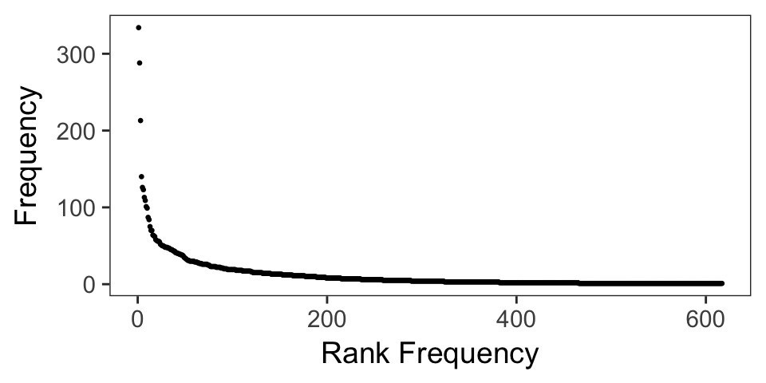

```r
ggplot(referents, aes(x = rank, y = freq, group = 1)) +
  geom_point(size = .5) +
  xlab("Rank Frequency") +
  ylab("Frequency")
```

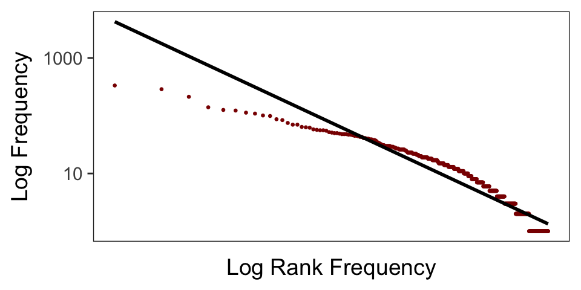

```r
ggplot(referents, aes(x = rank, y = freq, group = 1)) +
  geom_point(size = .5, color = "darkred") +
  geom_smooth(method = "lm", se = FALSE, color = "black") +
  scale_y_log10(name = "Log Frequency") +
  scale_x_log10(name = "Log Rank Frequency") +
  theme(axis.text.x = element_blank(), axis.ticks.x = element_blank())
```

It looks like our referent frequency distribution is not actually well described by Zipf’s law (yet?). There aren’t enough low frequency referents in the tail. Let’s try with just words:

Plot referent frequences in normal and log-log scale

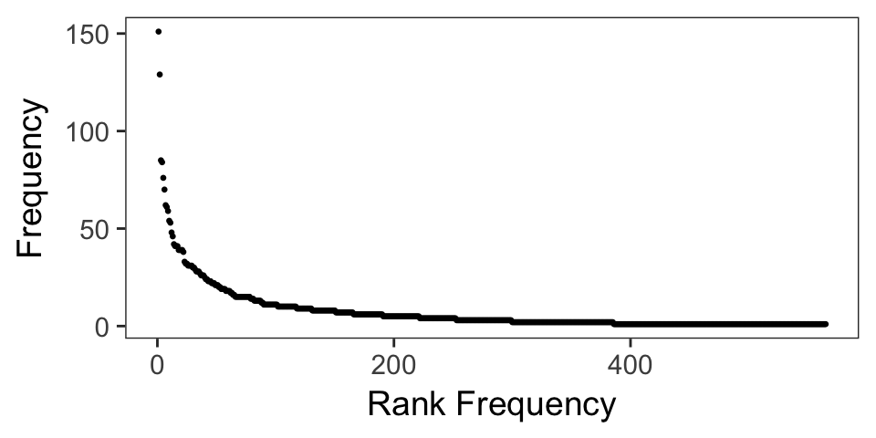

```r
ggplot(spoken_referents, aes(x = rank, y = freq, group = 1)) +
  geom_point(size = .5) +
  xlab("Rank Frequency") +
  ylab("Frequency") +
  theme()
```

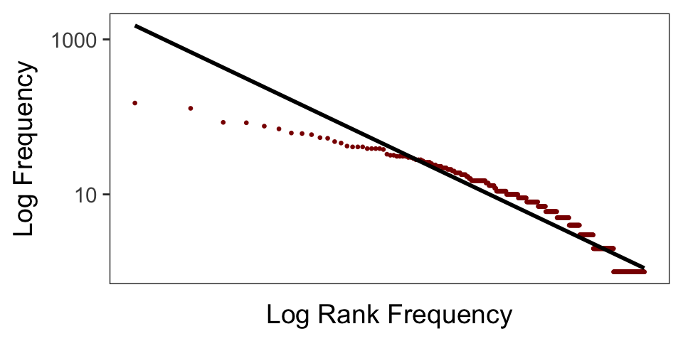

```r
ggplot(spoken_referents, aes(x = rank, y = freq, group = 1)) +
  geom_point(size = .5, color = "darkred") +
  geom_smooth(method = "lm", se = FALSE, color = "black") +
  scale_y_log10(name = "Log Frequency") +
  scale_x_log10(name = "Log Rank Frequency") +
  theme(axis.text.x = element_blank(), axis.ticks.x = element_blank())
```

Looks similar… Maybe things will look a bit better with more data coded? Interesting to think about why this isn’t Zipfian. Maybe we should think about discourse topics?

Ok, let’s try the main analysis: Does frequency predict speech/gesture?

```r
max_refs <- loaded_subjs %>%
  ungroup() %>%
  gather(ref_col, refs, spoken_obj, gestured_obj, referent) %>%
  mutate(num_refs = str_count(refs,";")) %>%
  summarise(num_refs = max(num_refs, na.rm = T)+1) %>%
  as.integer()

ref_list <- sapply(1:max_refs,function(x) paste0("referent",x))

spread_referents <- loaded_subjs %>%
  separate_("referent", ref_list, sep = ";", fill = "right") %>%
  gather_("number", "referent", ref_list) %>%
  filter(!is.na(referent)) %>%
  mutate(referent = str_trim(referent))

coded_responses <- spread_referents %>%
  mutate(spoken_obj = map(str_split(spoken_obj, ";"), str_trim),
         gestured_obj = map(str_split(gestured_obj, ";"), str_trim)) %>%
  rowwise() %>%
  mutate(spoken = purrr::contains(spoken_obj[[1]], referent),
         gestured = purrr::contains(gestured_obj[[1]], referent),
         both = spoken & gestured) %>%
  ungroup() %>%
  mutate(modality = if_else(spoken & gestured, "both",
                            if_else(spoken, "speech", "gesture"))) %>%
  select(time, subj, age, person, referent, modality, chat) %>%
  left_join(referents) %>%
  mutate(freq_cut = cut(log(freq), 4))

modality_data <- coded_responses %>%
  group_by(person, age, subj, freq_cut, rank, freq, referent, modality, chat) %>%
  summarise(n = n()) %>%
  spread(modality, n, fill = 0)
```

Does parent/child production of reference in *both* modalities simultaneously changes with age and word frequency?

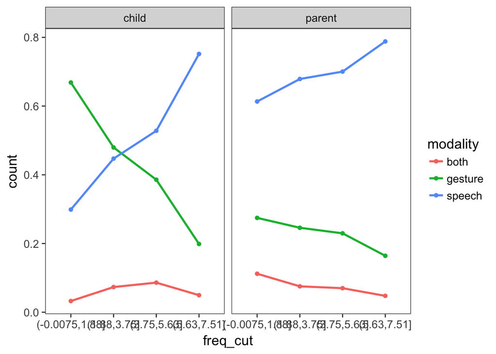

```r
both_data <- modality_data %>%
  group_by(person, age, freq_cut) %>%
  summarise(both = sum(both), gesture = sum(gesture), speech = sum(speech)) %>%
  gather(modality, count, both, gesture, speech) %>%
  group_by(person, freq_cut, age) %>%
  mutate(count = count/sum(count)) %>%
  group_by(person, freq_cut, modality) %>%
  summarise(count = mean(count))

ggplot(aes(x = freq_cut, y = count, color = modality, group = modality),
       data = both_data) +
  facet_wrap(~ person) +
  geom_point() +
  theme(legend.position = "right") +
  geom_smooth(se = FALSE)
```

Try making Frank et al. style Gleitman plots. It turns out we have too many different referents… Here are a few ways of collapsing the data to get a better sense for it

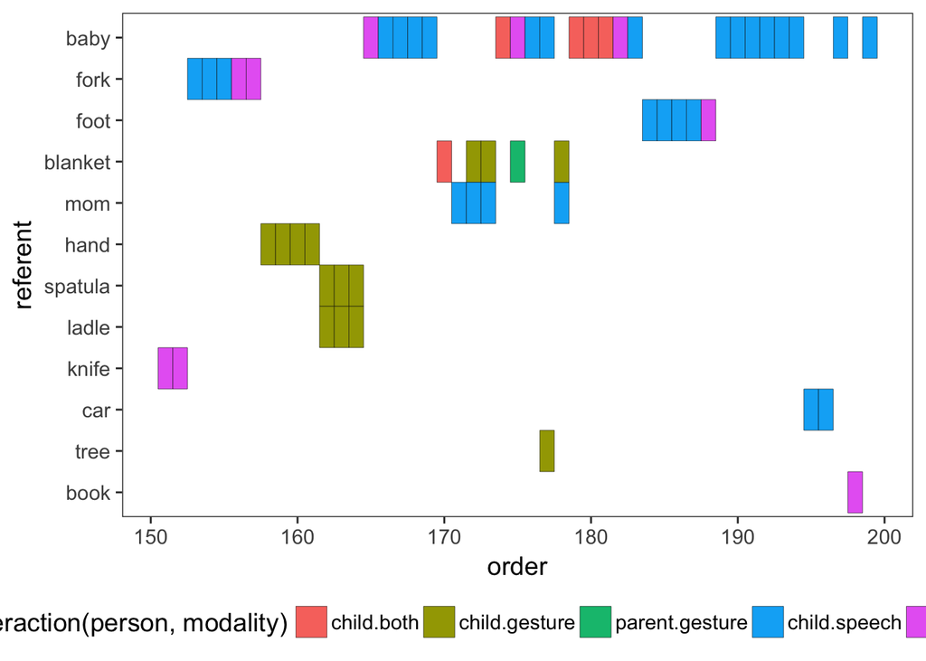

```r
gleitman_data <- coded_responses %>%
  filter(subj == 29, age == 22) %>%
  mutate(order = as.numeric(as.factor(time))) %>%
  filter(order > 150, order < 200)

ref_freqs <- gleitman_data %>%
  group_by(referent) %>%
  summarise(n = n()) %>%
  arrange(n)

gleitman_sorted <- gleitman_data %>%
  mutate(referent = factor(referent, levels = ref_freqs$referent))


ggplot(aes(x = order, y = referent, fill = interaction(person, modality)),
           data = gleitman_sorted) +
  geom_tile(color = "black") +
  theme(legend.position = "bottom")
```

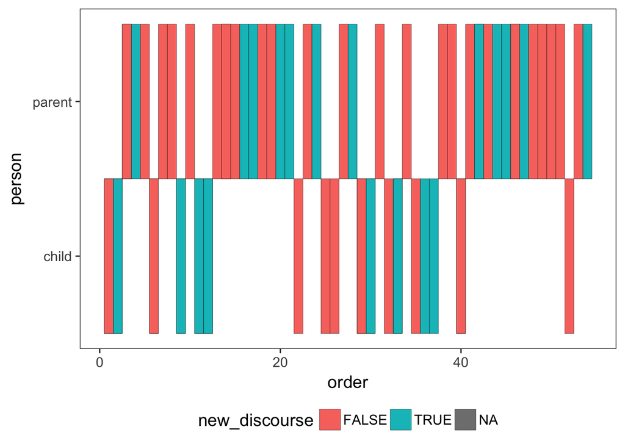

```r
discourse_data <- coded_responses %>%
  filter(subj == 33, age == 22) %>%
  mutate(order = as.numeric(as.factor(time))) %>%
  filter(order > 0, order < 55) %>%
  mutate(new_discourse = lag(referent) == referent)



ggplot(aes(x = order, y = person, fill = new_discourse), data = discourse_data) +
  geom_tile(color = "black") +
  theme(legend.position = "bottom")
```

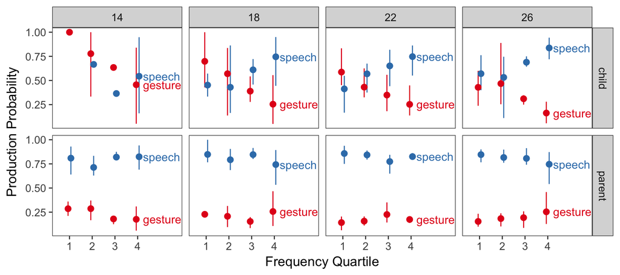

```r
plotting_data <- coded_responses %>%
  filter(modality != "both") %>%
  group_by(person, age, subj, freq_cut, modality) %>%
  summarise(n = n()) %>%
  mutate(prob = n/sum(n)) %>%
  group_by(person, age, modality, freq_cut) %>%
  multi_boot_standard("prob")

ggplot(plotting_data, aes(x = as.numeric(freq_cut), y = mean, color = modality,
                          label = modality)) +
  facet_grid(person ~ age) +
  geom_pointrange(aes(ymax = ci_upper, ymin = ci_lower),
                  position = position_dodge(.25)) +
  scale_color_brewer(palette = "Set1") +
  geom_dl(method = list(dl.trans(x=x +.2), "last.qp", cex=1)) +
  scale_x_continuous(limits = c(.5, 5.7),
                     breaks = seq(1, 4),
                     name = "Frequency Quartile") +
  ylab("Production Probability")
```

Now lets fit some statistical models to this to see if the effects are robust

```r
tidy_table <- function(mermod) {
  tidy(mermod) %>%
    filter(group == "fixed") %>%
    select(-group)
}

child_lm <- glmer(cbind(speech, gesture) ~ age * log(freq) +
                    (1|referent) + (1|subj),
      data = filter(modality_data, person == "child"),
      family = "binomial")

datatable(tidy_table(child_lm), rownames = FALSE,
          options = list(searching = FALSE), width = 400)
```

| term | estimate | std.error | statistic | p.value |
| --- | --- | --- | --- | --- |
| (Intercept) | -8.14007501282006 | 1.34860389458355 | -6.03592726189902 | 1.58052440476154e-09 |
| age | 0.349268347410453 | 0.0580687341303164 | 6.01474016338351 | 1.8017546466029e-09 |
| log(freq) | 1.4783270693134 | 0.333609917462214 | 4.43130432260258 | 9.36647878339047e-06 |
| age:log(freq) | -0.0525979183968986 | 0.0143164448675337 | -3.6739511019372 | 0.000238828456749127 |

```r
parent_lm <- glmer(cbind(speech, gesture) ~ age + log(freq) +
                    (1|referent) + (1|subj),
      data = filter(modality_data, person == "parent"),
      family = "binomial")

datatable(tidy_table(parent_lm), rownames = FALSE,
          options = list(searching = FALSE), width = 400)
```

| term | estimate | std.error | statistic | p.value |
| --- | --- | --- | --- | --- |
| (Intercept) | 1.1785115794842 | 0.306822678327274 | 3.84101848634256 | 0.000122524885832789 |
| age | 0.0280719587727824 | 0.0107331678395143 | 2.61544021229548 | 0.00891125209415103 |
| log(freq) | -0.0203278115834366 | 0.0600293054933829 | -0.338631463688638 | 0.734887376972936 |

Let’s also check whether production of *both* modalities simultaneously changes over development and frequency

```r
child_both_lm <- glmer(cbind(both, speech + gesture) ~ age * log(freq) +
                    (1|referent) + (1|subj),
      data = filter(modality_data, person == "child"),
      family = "binomial")

datatable(tidy_table(child_both_lm), rownames = FALSE,
          options = list(searching = FALSE), width = 400)
```

[output not shown]

```r
parent_both_lm <- glmer(cbind(both, speech + gesture) ~ age + log(freq) +
                    (1|referent) + (1|subj),
      data = filter(modality_data, person == "parent"),
      family = "binomial")

datatable(tidy_table(parent_both_lm), rownames = FALSE,
          options = list(searching = FALSE), width = 400)
```

[output not shown]